# Tree Based Methods

10/31/2019

## Agenda

- Regression trees
- Classification trees
- Bagging and Random Forests
- Variable Importance measures
- Boosting trees

## Introduction

- Here we describe tree-based methods for regression and classification
- These involve stratifying or segmenting the **predictor space** into a number of simple regions
- Since the set of splitting rules used to segment the predictor space can be summarized in a tree, these types of approaches are known as decision-tree methods

\[\widehat{Y} = \widehat{f}(X) = \text{Tree}(X)\]

## Decision trees for regression

## One dimensional example

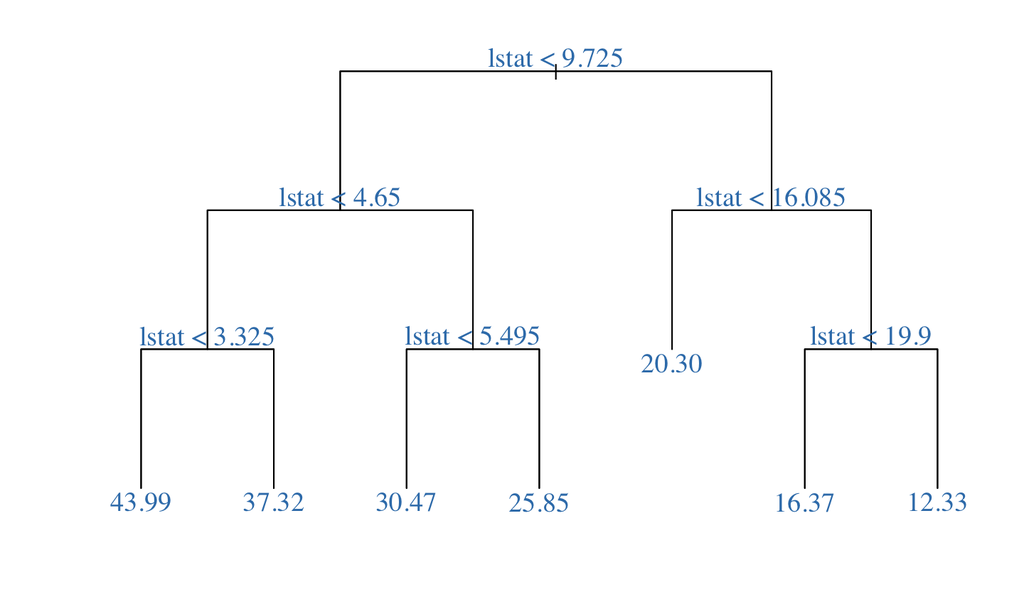

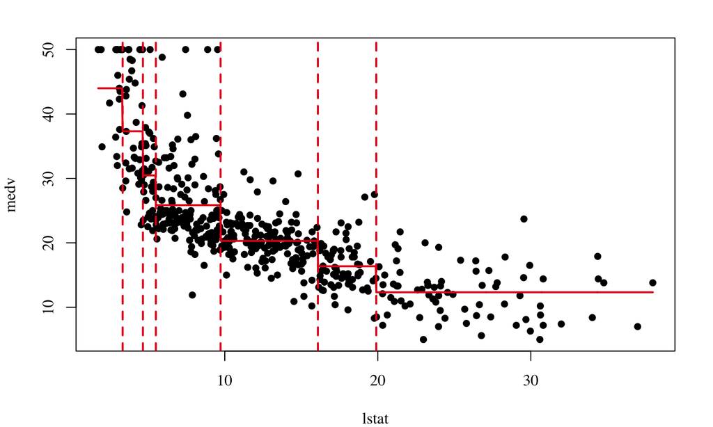

At each **internal node** there is a decision rule of the form \(\{x < c\}\): if \(x < c\) go left, otherwise go right

- Every rule adds a split in the predictor space
- The set of **leaves** (bottom nodes) gives us a partition of the predictor space \(\mathcal{X}\) into disjoint regions (with just one \(X\), it is a set of intervals)

## One dimensional example

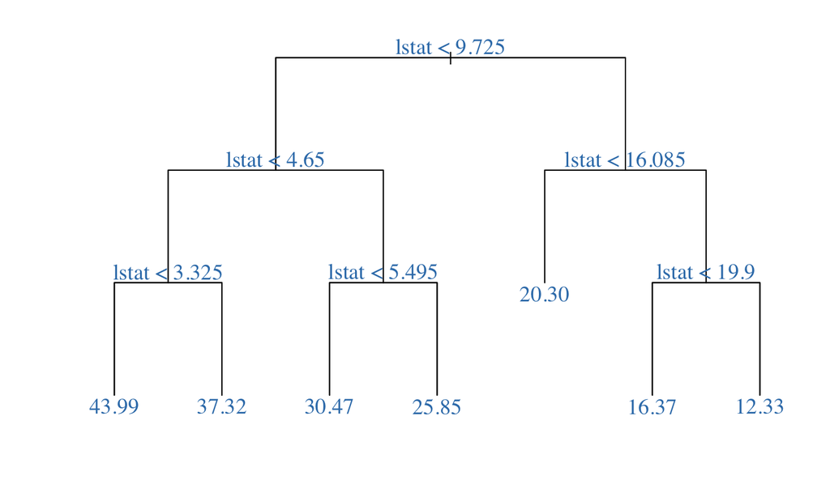

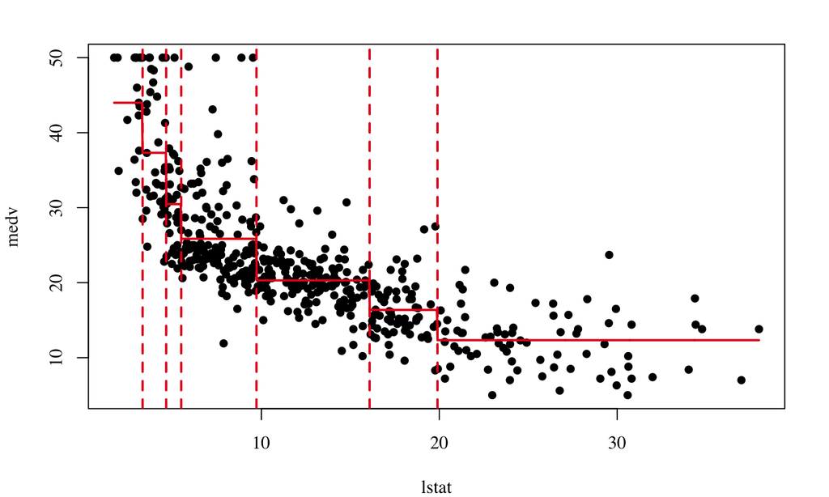

Within each region (interval) we compute the average of the \(y\) values for the subset of training data in the region

- This gives us an estimated \(\hat{f}\) (step function)
- To predict, we drop \(x\) down the tree until it lands in a leaf and then predict the average of the \(y\) values for the training observations in the same leaf

## Two dimensional example

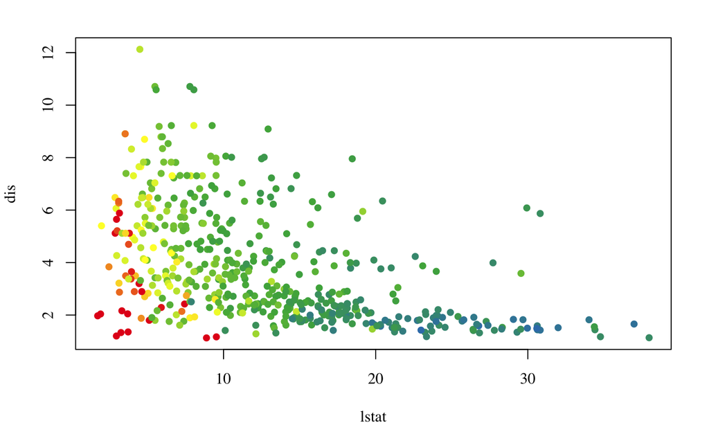

## Two dimensional example

Now the decision rules can use either of the two \(x\)’s.

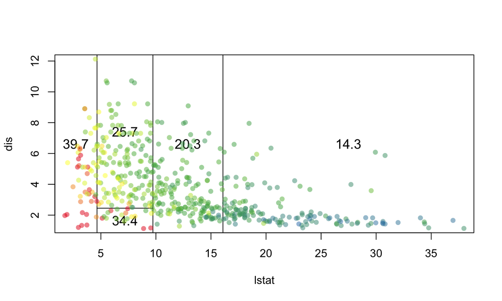

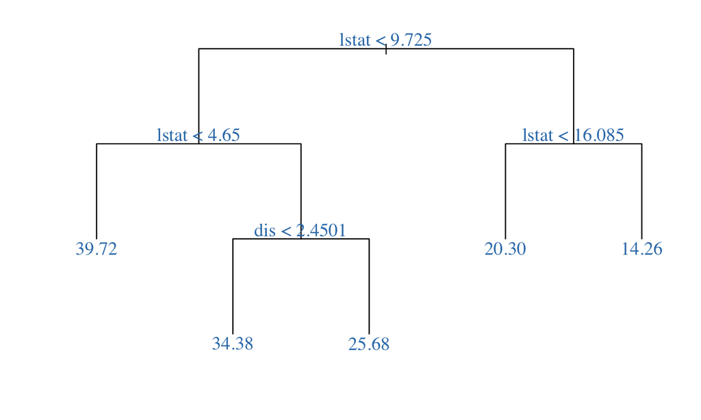

## Two dimensional example

- Regression function given by the tree
- It is a “step-like” function
- It delivers non-linearity and interactions in a simple way
- It works with a lot of variables

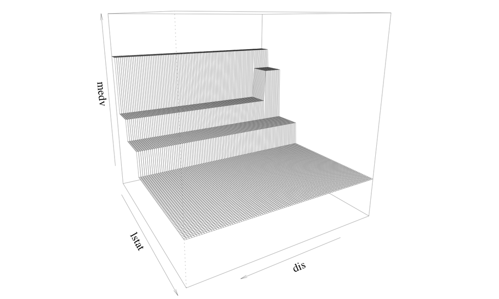

## Interpretation of results

- `lstat` (\(\%\) lower status of the population) is the most important factor in determining `medv` (median value of houses), and houses with lower `lstat` have higher values compared to houses with larger `lstat`
- Given that a house is in a neighbourhood with large `lstat`, the distance to employment centres seems to play little role in the house value

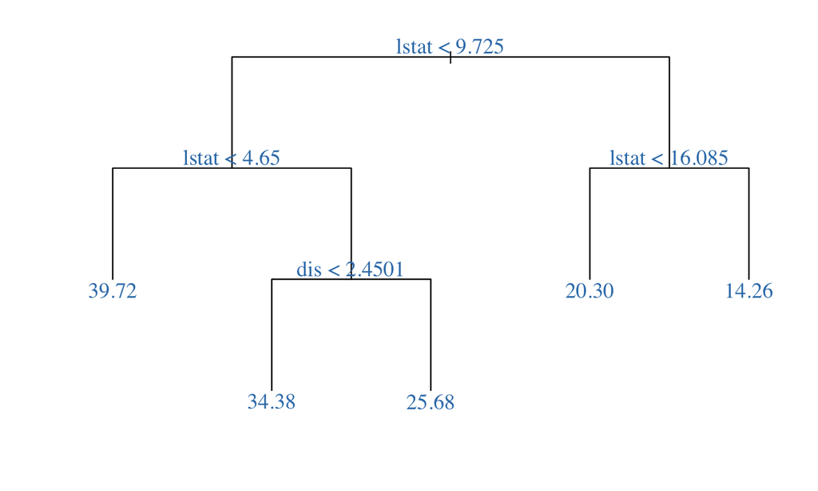

\[\text{ }\]

However, among neighbourhoods with smaller `lstat`, the distance to employment centres does affect the house value, and houses that are closer to employment centres have higher values

## Shallow vs deep trees

Let’s see a deeper version of the previous tree.

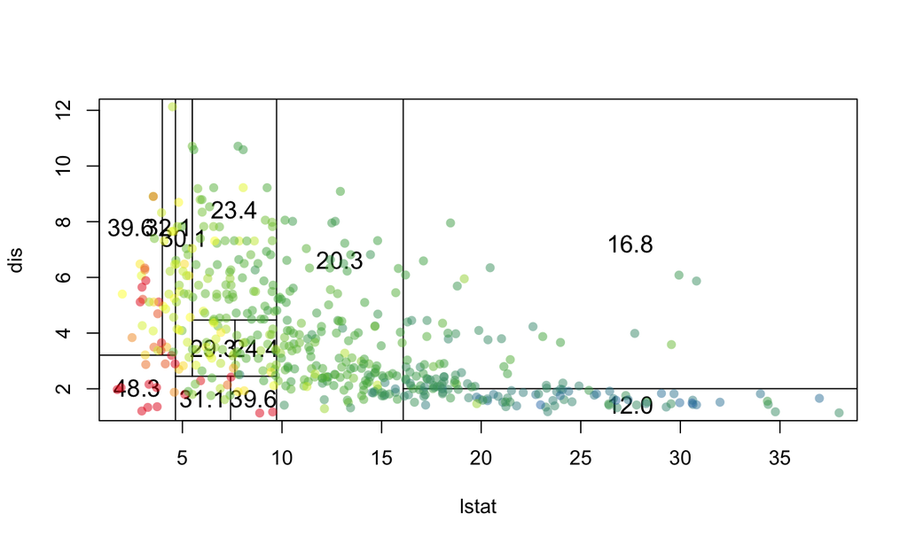

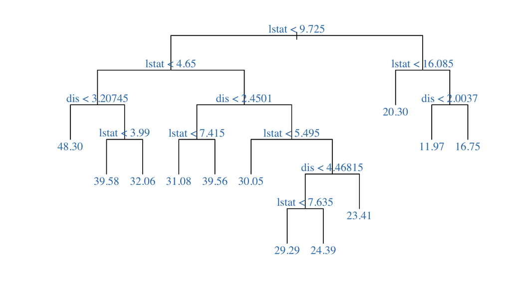

## Shallow vs deep trees

Notice the interaction: the effect of `dis` depends on `lstat`!

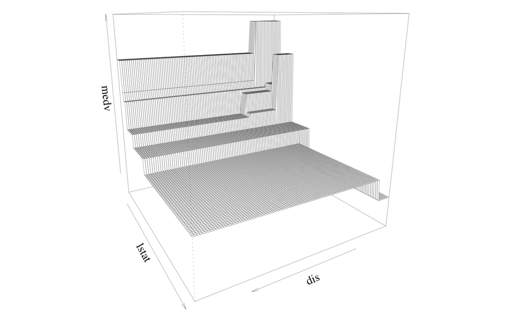

## Details of the tree building process

- We divide the predictor space - that is, the set of possible values for \(X_1, X_2, \dots, X_p\) - into \(J\) distinct and non-overlapping regions \(R_1, R_2, \dots, R_J\)
- For every observation that falls into the region \(R_j\), we make the same prediction \(\hat{y}_{R_j}\), which is simply the mean of the response values for the training observations in \(R_j\)
- In theory, the regions could have any shape. However, we choose to divide the predictor space into high-dimensional rectangles, or boxes, for simplicity and for ease of interpretation of the resulting predictive model
- The goal is to find boxes \(R_1, \dots, R_J\) that minimize the RSS, given by \(J\) where \[\sum_{j=1}^J \sum_{i \in R_j} (y_i - \hat{y}_{R_j})^2\]

## Details of the tree building process

- Unfortunately, it is computationally infeasible to consider every possible partition of the feature space into \(J\) boxes
- For this reason, we take a **top-down**, **greedy** approach that is known as recursive binary splitting
- The approach is **top-down** because it begins at the top of the tree and then successively splits the predictor space; each split is indicated via two new branches further down on the tree
- It is **greedy** because at each step of the tree-building process, the best split is made at that particular step, rather than looking ahead and picking a split that will lead to a better tree in some future step

## Pruning a tree

- The process described above may produce good predictions on the training set, but is likely to **overfit the data**, leading to poor test set performance. Why?
- A smaller tree with fewer splits (that is, fewer regions \(R_1, \dots, R_J\)) might lead to lower variance and better interpretation at the cost of a little bias
- One possible alternative to the process described above is to grow the tree only so long as the decrease in the RSS due to each split exceeds some (high) threshold
- This strategy will result in smaller trees, but it is too short-sighted: a seemingly worthless split early on in the tree might be followed by a very good split - that is, a split that leads to a large reduction in RSS later on

## Pruning a tree

- A better strategy is to grow a very large tree \(T_0\), and then **prune** it back in order to obtain a subtree
- We consider a sequence of trees indexed by a nonnegative tuning parameter \(\alpha\). For each value of \(\alpha\) there corresponds a subtree \(T \subset T_0\) such that \[C_{\alpha}(T) = \sum_{m=1}^{|T|} \sum_{i \text{ s.t. } x_i \in R_m} (y_i - \hat{y}_{R_m})^2 + \alpha |T|\] is as small as possible. Here \(|T|\) indicates the number of terminal nodes of the tree \(T\)
- Given a current pruned tree, examine every pair of bottom nodes (having the same parent node) and consider eliminating the pair. Prune the pair that gives the biggest decrease in our criterion \(C_{\alpha}(T)\). This gives us a sequence of subtrees of our initial big tree

## Pruning a tree

- The tuning parameter \(\alpha\) controls a trade-off between the subtree’s complexity and its fit to the training data (it should remind you of \(\lambda\) in the lasso)
- We select an optimal value \(\hat{\alpha}\) using cross-validation
- We then return to the full data set and obtain the subtree corresponding to \(\hat{\alpha}\)

## Bias variance tradeoff

As we saw, the key idea is that a complex tree is a big tree. We usually measure the complexity of the tree by the number of leaves.

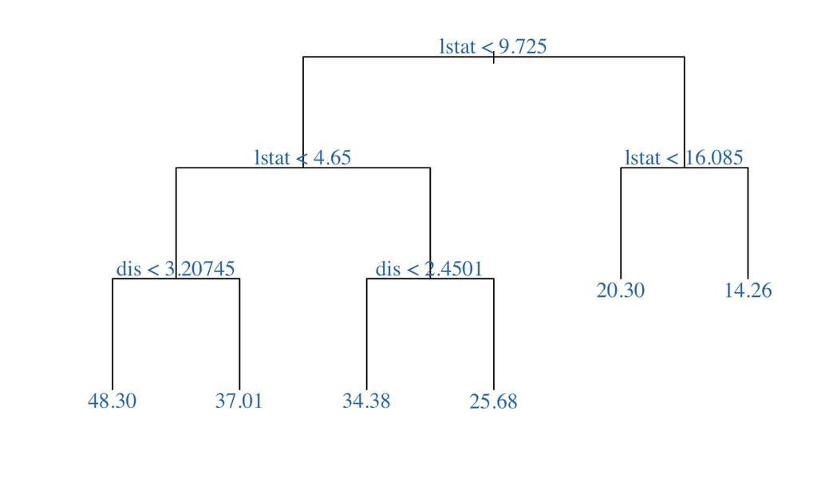

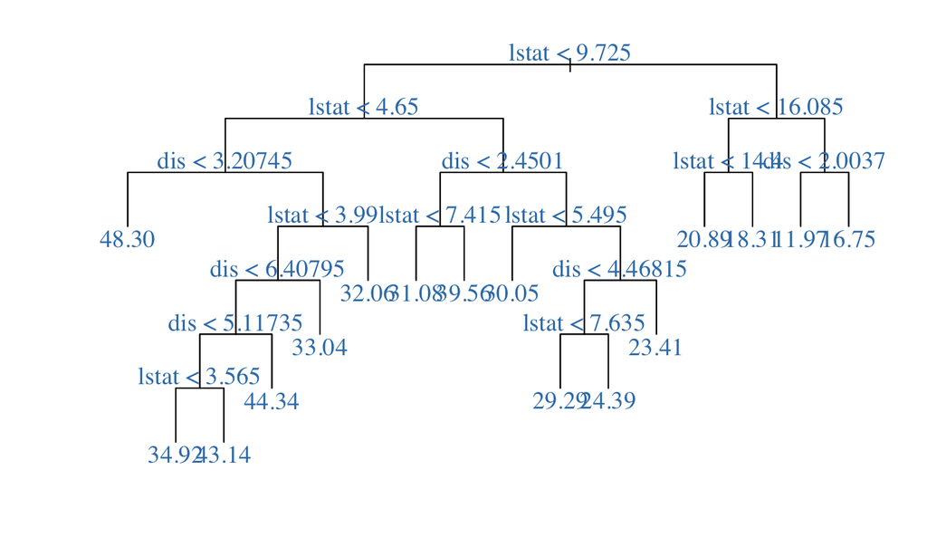

## Classification trees

## Classification trees

- Very similar to a regression tree, except that it is used to predict a qualitative response rather than a quantitative one
- For a classification tree, we predict that each observation belongs to the most commonly occurring class of training observations in the region to which it belongs
- Just as in the regression setting, we use recursive binary splitting to grow a classification tree \[C_{\alpha}(T) = \text{RSS} + \alpha |T|\]
- In the classification setting, RSS cannot be used as a criterion for making the binary splits: we could use the misclassification rate

## Classification trees

However, in practice two other measures are preferable: the **Gini index** and the **entropy**.

The Gini index is defined by \[G_m = \sum_{k=1}^K \hat{p}_{mk} (1 - \hat{p}_{mk}),\] where \(\hat{p}_{mk}\) represents the proportion of observations in the \(m^{th}\) region that are from the \(k^{th}\) class. It is a measure of total variance across the \(K\) classes.

An alternative to the Gini index is entropy, given by \[D_m = - \sum_{k=1}^K \hat{p}_{mk} \log(\hat{p}_{mk})\]

## Example

Hockey penalty data: the response is whether or not the next penalty is on the other team and \(x\) contains a bunch of variables about the current game (score, …).

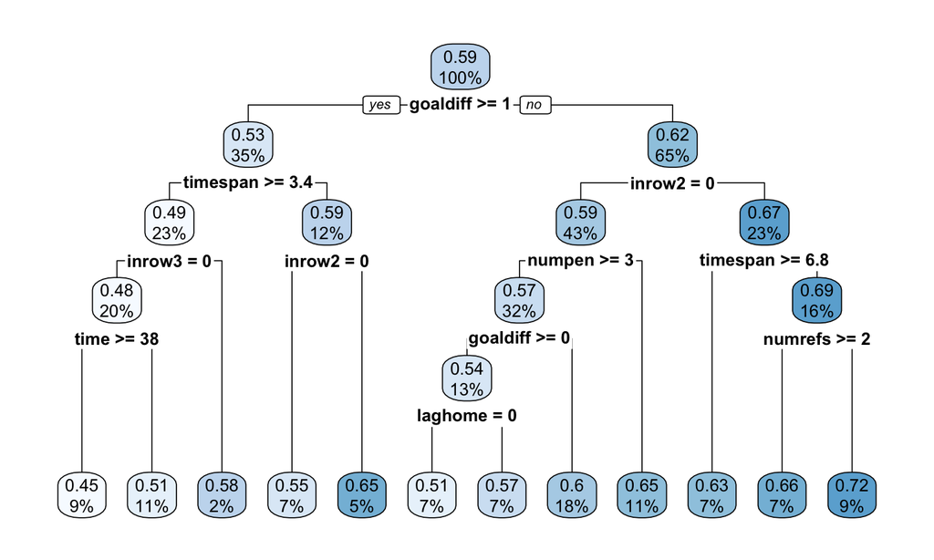

## Example

The form of the decision rule cannot be \(\{x < c\}\) for categorical variables: the tree picks a subset of the levels to go left. `inrow2` = 0 means that all the observations with `inrow2` in the category labeled 0 go left.

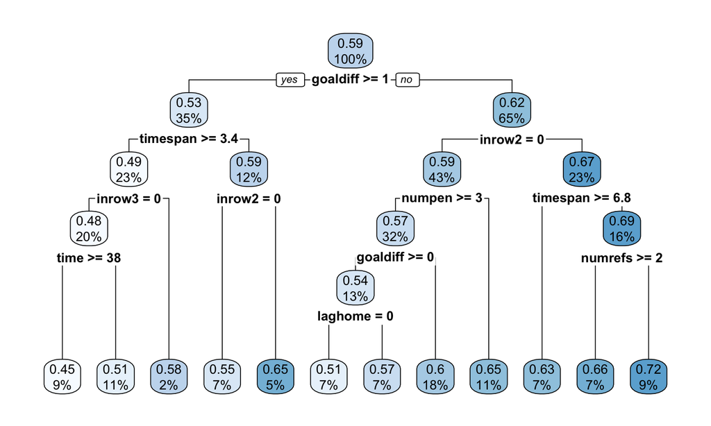

If:

- you are not winning
- you had the last two penalties
- it has not been long since the last call
- and there is only 1 referee

then there is a \(72\%\) chance the next call will be on the other team.

## Recap

## Pros and cons

Good:

- Flexible fitters, capture non-linearity and interactions
- The scale of variables does not matter
- Handles both categorical and numeric \(y\) and \(X\) very nicely
- Simple interpretation (if the tree is small)

Bad:

- Not the best in out-of-sample predictive performance

## Sacrificing interpretation for performance

If we **bag** or **boost** trees, we can get the best off-the-shelf prediction available.

The idea is to combine a large number (hundreds, thousands) of trees to get an overall predictor.

Ensemble methods: we can improve predictive accuracy at the expense of some loss of interpretation.

Details in the next class…

## Test

What tree has probably larger variance?

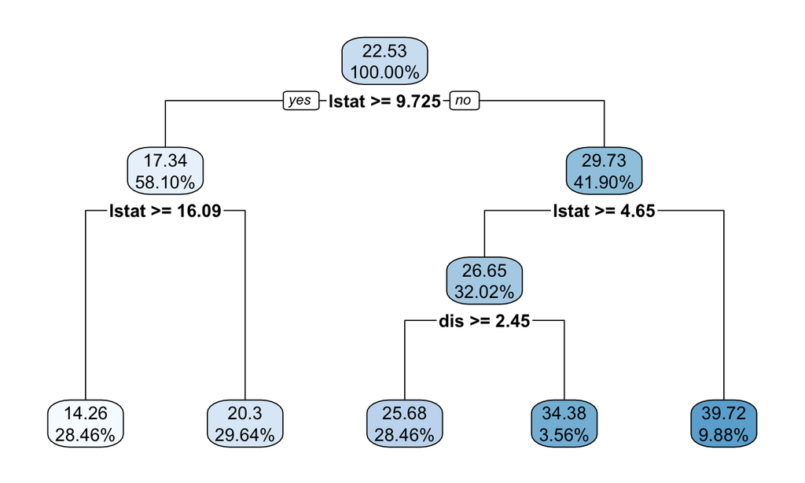

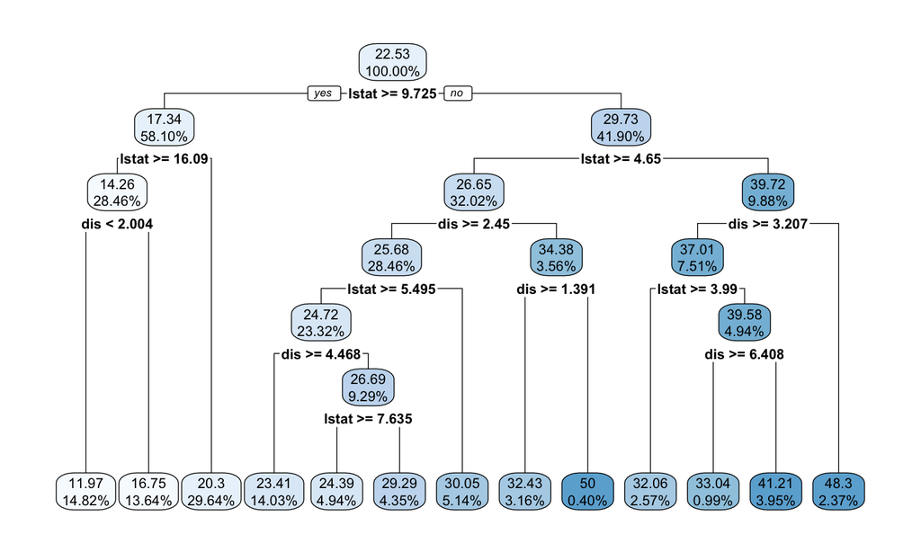

## Test

What would you predict for the value of a house with `lstat` = 6 and `dis` = 3?

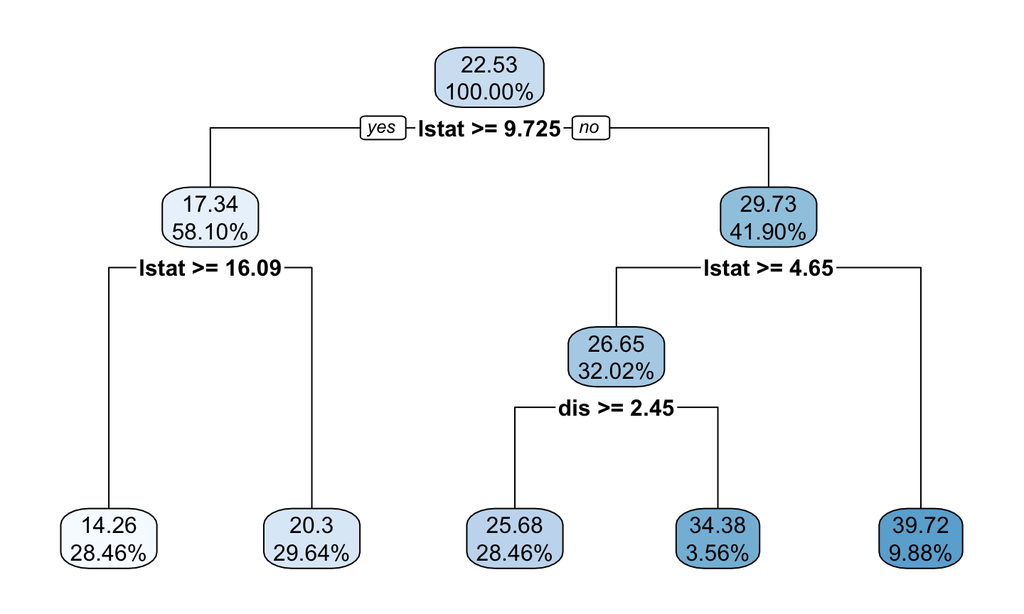

1. 39.72
2. 14.26
3. 25.68
4. (25.68 + 34.38)/2